# HW1-IE582

Tümay Kır

11/20/2020

# Homework-1: Analysis of English Premier League Data

## 1.Task1

The data for different three seasons is merged in a larger dataframe called `data`.

```r
data1<-read.csv("C:/Users/tumay/Desktop/E0.csv")
data1<-data1[,1:56]
data2<-read.csv("C:/Users/tumay/Desktop/E1.csv")
data2<-data2[,1:53]
data3<-read.csv("C:/Users/tumay/Desktop/E2.csv")
data3<-data3[,1:56]
data<-merge(data1, data3, by = intersect(names(data1), names(data3)), all = TRUE)
data<-merge(data2, data, by = intersect(names(data), names(data2)), all = TRUE)

data<-data[order(as.Date(data$Date, format="%d/%m/%Y")),]
head(data)
```

```
##     Div       Date     HomeTeam       AwayTeam FTHG FTAG FTR HTHG HTAG HTR
## 274  E0 10/08/2018   Man United      Leicester    2    1   H    1    0   H
## 304  E0 11/08/2018  Bournemouth        Cardiff    2    0   H    1    0   H
## 305  E0 11/08/2018       Fulham Crystal Palace    0    2   A    0    1   A
## 306  E0 11/08/2018 Huddersfield        Chelsea    0    3   A    0    2   A
## 307  E0 11/08/2018    Newcastle      Tottenham    1    2   A    1    2   A
## 308  E0 11/08/2018      Watford       Brighton    2    0   H    1    0   H
##        Referee HS AS HST AST HF AF HC AC HY AY HR AR B365H B365D B365A  BWH BWD
## 274 A Marriner  8 13   6   4 11  8  2  5  2  1  0  0  1.57   3.9  7.50 1.53 4.0
## 304   K Friend 12 10   4   1 11  9  7  4  1  1  0  0  1.90   3.6  4.50 1.90 3.4
## 305     M Dean 15 10   6   9  9 11  5  5  1  2  0  0  2.50   3.4  3.00 2.45 3.3
## 306 C Kavanagh  6 13   1   4  9  8  2  5  2  1  0  0  6.50   4.0  1.61 6.25 3.9
## 307 M Atkinson 15 15   2   5 11 12  3  5  2  2  0  0  3.90   3.5  2.04 3.80 3.5
## 308     J Moss 19  6   5   0 10 16  8  2  2  2  0  0  2.37   3.2  3.40 2.35 3.1
##      BWA  IWH  IWD  IWA  PSH  PSD  PSA  WHH WHD  WHA  VCH VCD  VCA Bb1X2 BbMxH
```

[output cut: 27 more lines]

### 1.1. Histograms

The histogram of the home goals is plotted.

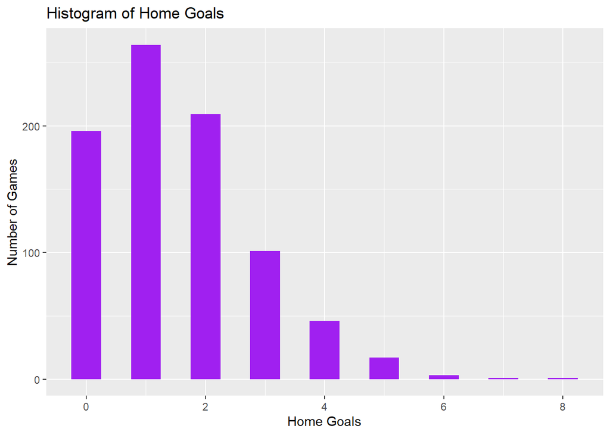

```r
ggplot(data) + geom_histogram(aes(x = FTHG), binwidth=0.5,fill="purple")+
  xlab("Home Goals") + ylab("Number of Games") + ggtitle("Histogram of Home Goals")
```

The histogram of the away goals is plotted.

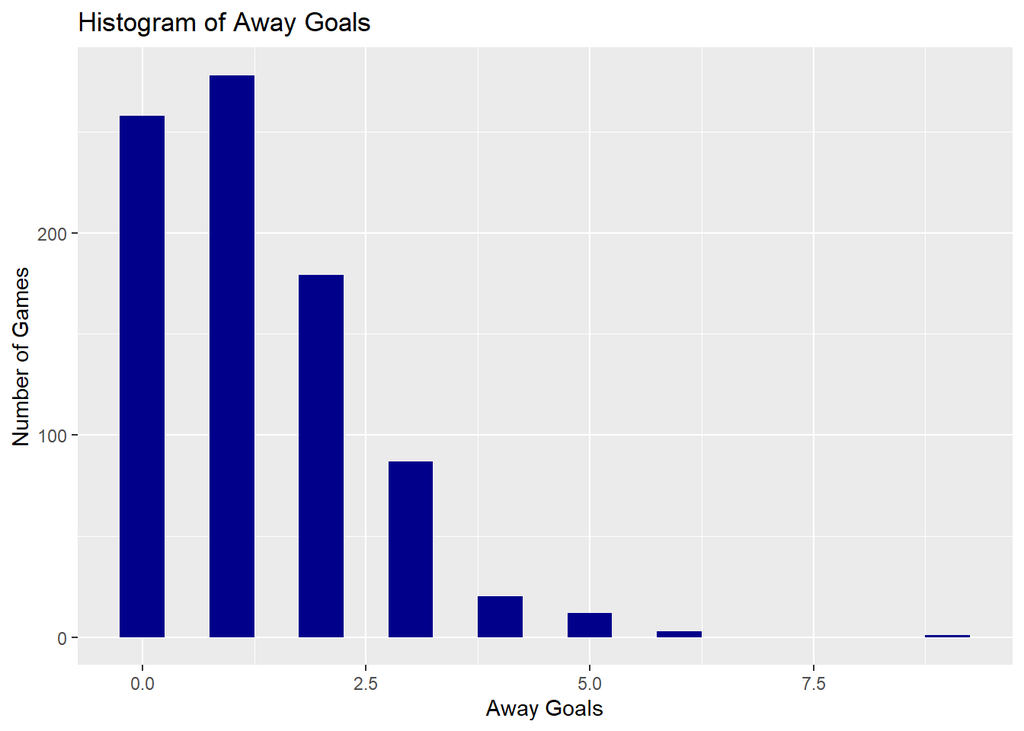

```r
ggplot(data) + geom_histogram(aes(x = FTAG), binwidth=0.5,fill="darkblue")+
  xlab("Away Goals") + ylab("Number of Games") + ggtitle("Histogram of Away Goals")
```

The histogram of the difference between home goals and away goals is plotted.

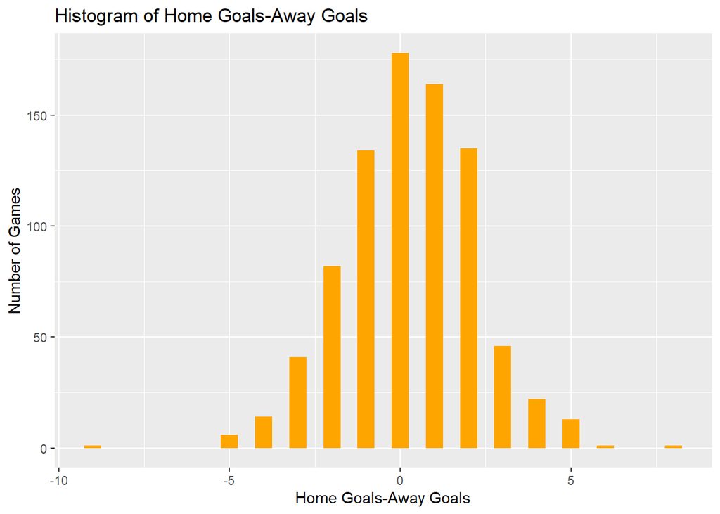

```r
ggplot(data) + geom_histogram(aes(x = FTHG-FTAG), binwidth=0.5,fill="orange")+
  xlab("Home Goals-Away Goals") + ylab("Number of Games") + ggtitle("Histogram of Home Goals-Away Goals")
```

### 1.2. Histograms with Distributions

The histogram of home goals looks like it is distributed with Poisson.

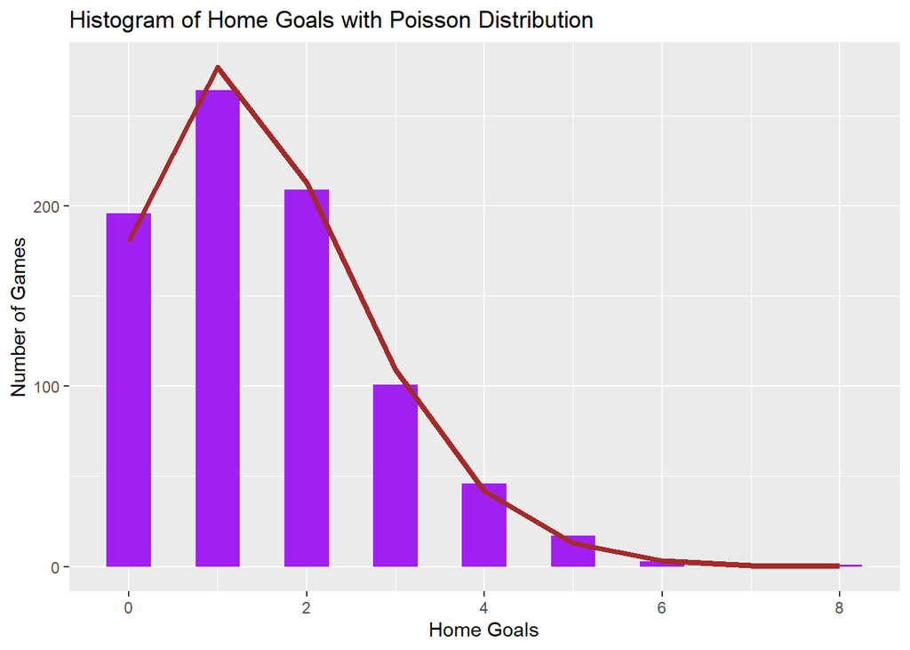

```r
hist_home<-ggplot(data) + geom_histogram(aes(x = FTHG), binwidth=0.5,fill="purple")+
  xlab("Home Goals") + ylab("Number of Games") + ggtitle("Histogram of Home Goals with Poisson Distribution")
xfit = seq(0,max(data[,"FTHG"]),1)
yfit = dpois(xfit,lambda=mean(data[,"FTHG"]))
yfit<-yfit*length(data[,"FTHG"])
home_fits<-data.frame(xfit,yfit)
hist_home+
  geom_line(data=home_fits,aes(x=xfit,y=yfit),color="brown",size=1.5)
```

The histogram of away goals looks like it is distributed with Poisson.

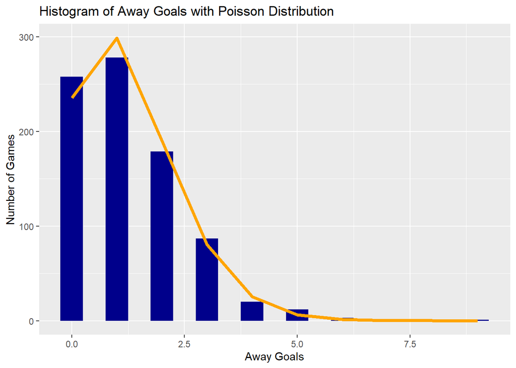

```r
hist_away<-ggplot(data) + geom_histogram(aes(x = FTAG), binwidth=0.5,fill="darkblue")+
  xlab("Away Goals") + ylab("Number of Games") + ggtitle("Histogram of Away Goals with Poisson Distribution")
xfit = seq(0,max(data[,"FTAG"]),1)
yfit = dpois(xfit,lambda=mean(data[,"FTAG"]))
yfit<-yfit*length(data[,"FTAG"])
away_fits<-data.frame(xfit,yfit)
hist_away+
  geom_line(data=away_fits,aes(x=xfit,y=yfit),color="orange",size=1.5)
```

The histogram of the difference between home and away goals looks like it is distributed with Skellam (difference of two Poissons).

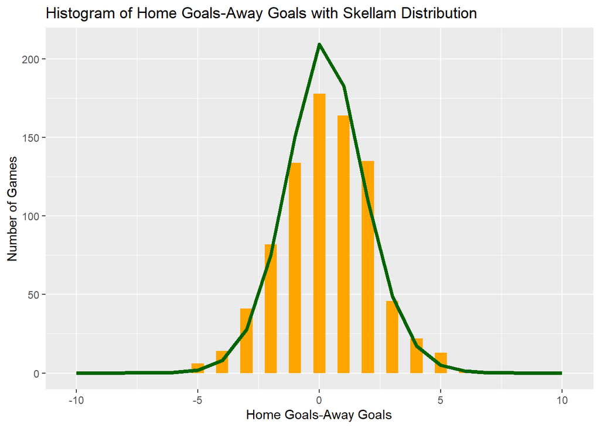

```r
diff_hist<-ggplot(data) + geom_histogram(aes(x = FTHG-FTAG), binwidth=0.5,fill="orange")+
  xlab("Home Goals-Away Goals") + ylab("Number of Games") + ggtitle("Histogram of Home Goals-Away Goals with Skellam Distribution")
xfit = seq(-10,10,1)
yfit = dskellam(xfit,lambda1=mean(data$FTHG),lambda2=mean(data$FTAG))
yfit=yfit*length(data$FTHG)
diff_fits<-data.frame(xfit,yfit)
diff_hist+geom_line(data=diff_fits,aes(x=xfit,y=yfit),color="darkgreen",size=1.5)
```

## 2.Task2

For the bookmaker Bet365, the probability calculations are done and they are normalized.

### Bet365

```r
data<-data%>% mutate(prob_home_365=1/B365H)
data<-data%>% mutate(prob_away_365=1/B365A)
data<-data%>% mutate(prob_draw_365=1/B365D)
data<-data%>% mutate(total_prob_365=(prob_home_365+prob_draw_365+prob_away_365))
data<-data%>% mutate(normalized_home_365=prob_home_365/total_prob_365)
data<-data%>% mutate(normalized_away_365=prob_away_365/total_prob_365)
data<-data%>% mutate(normalized_draw_365=prob_draw_365/total_prob_365)
head(data[,69:75])
```

```
##   prob_home_365 prob_away_365 prob_draw_365 total_prob_365 normalized_home_365
## 1     0.6369427     0.1333333     0.2564103       1.026686           0.6203869
## 2     0.5263158     0.2222222     0.2777778       1.026316           0.5128205
## 3     0.4000000     0.3333333     0.2941176       1.027451           0.3893130
## 4     0.1538462     0.6211180     0.2500000       1.024964           0.1500991
## 5     0.2564103     0.4901961     0.2857143       1.032321           0.2483824
## 6     0.4219409     0.2941176     0.3125000       1.028559           0.4102255
##   normalized_away_365 normalized_draw_365
## 1           0.1298677           0.2497455
## 2           0.2165242           0.2706553
## 3           0.3244275           0.2862595
## 4           0.6059900           0.2439110
## 5           0.4748487           0.2767689
## 6           0.2859513           0.3038232
```

The bins are created for Bet365 with the intervals of 0.05. By counting the number of “draw” match results and dividing them by the total number of games in the corresponding bin, the estimated probabilities are obtained.

```r
bins=seq(-1,1,0.05)
draw<-data%>%filter(FTR=="D")

draw<-draw%>%mutate(interval_365=cut(draw$normalized_home_365-draw$normalized_away_365,bins))
data<-data%>%mutate(interval_365=cut(data$normalized_home_365-data$normalized_away_365,bins))
counted<-draw%>%group_by(interval_365)%>%count()
counted_all<-data%>%group_by(interval_365)%>%count()
ratio<-merge(counted,counted_all,by="interval_365")
ratio<-ratio%>%mutate(ratio=n.x/n.y)
x<-data%>%group_by(interval_365)%>%summarise(meandiff=mean(normalized_home_365-normalized_away_365))
ratio<-merge(ratio,x,by="interval_365")
```

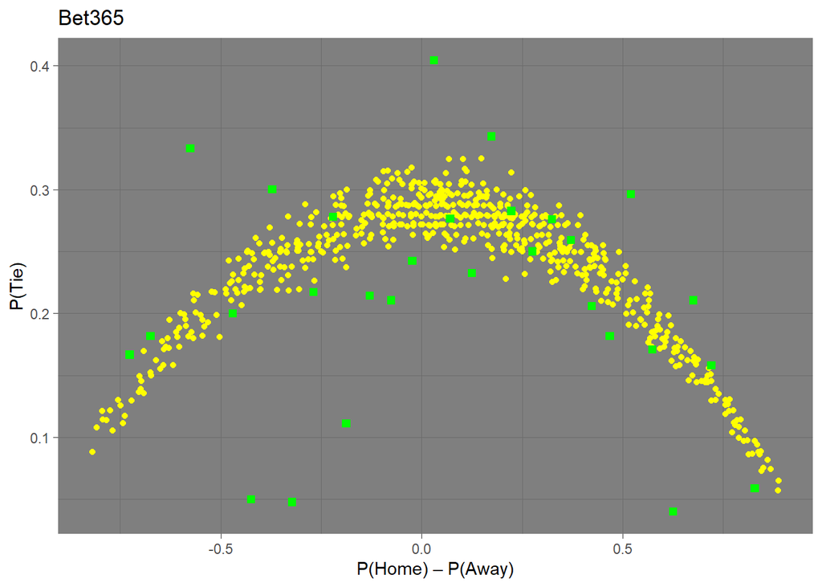

```r
ggplot(data=data,aes(x=normalized_home_365-normalized_away_365, y=normalized_draw_365))+
  geom_point(color="yellow")+geom_point(data=ratio,aes(meandiff,ratio),color="green",size=2,shape=15)+
  theme_dark()+xlab("P(Home) – P(Away)") + ylab("P(Tie)") + ggtitle("Bet365")
```

### BetAndWin

For the bookmaker BetAndWin, the probability calculations are done and they are normalized.

```r
data<-data%>% mutate(prob_home_BW=1/BWH)
data<-data%>% mutate(prob_away_BW=1/BWA)
data<-data%>% mutate(prob_draw_BW=1/BWD)
data<-data%>% mutate(total_prob_BW=(prob_home_BW+prob_draw_BW+prob_away_BW))
data<-data%>% mutate(normalized_home_BW=prob_home_BW/total_prob_BW)
data<-data%>% mutate(normalized_away_BW=prob_away_BW/total_prob_BW)
data<-data%>% mutate(normalized_draw_BW=prob_draw_BW/total_prob_BW)
```

The bins are created for BetAndWin with the intervals of 0.05. By counting the number of “draw” match results and dividing them by the total number of games in the corresponding bin, the estimated probabilities are obtained.

```r
bins=seq(-1,1,0.05)
draw<-data%>%filter(FTR=="D")

draw<-draw%>%mutate(interval_BW=cut(draw$normalized_home_BW-draw$normalized_away_BW,bins))
data<-data%>%mutate(interval_BW=cut(data$normalized_home_BW-data$normalized_away_BW,bins))
counted<-draw%>%group_by(interval_BW)%>%count()
counted_all<-data%>%group_by(interval_BW)%>%count()
ratio<-merge(counted,counted_all,by="interval_BW")
ratio<-ratio%>%mutate(ratio=n.x/n.y)

x<-data%>%group_by(interval_BW)%>%summarise(meandiff=mean(normalized_home_BW-normalized_away_BW))
ratio<-merge(ratio,x,by="interval_BW")
```

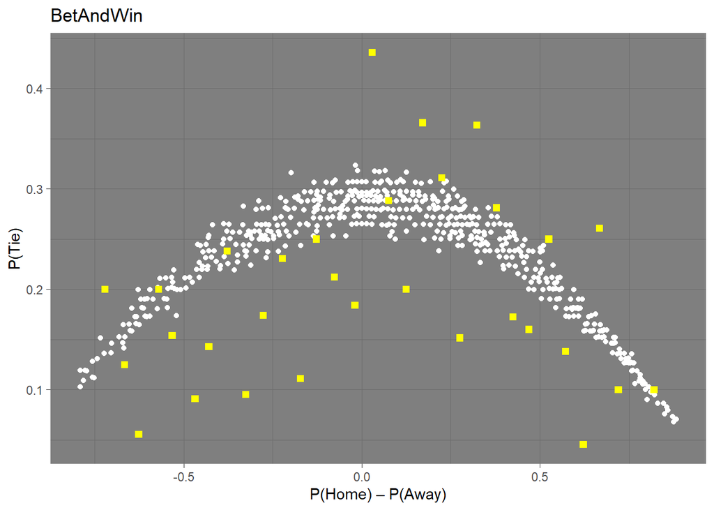

```r
ggplot(data=data,aes(x=normalized_home_BW-normalized_away_BW, y=normalized_draw_BW))+
  geom_point(color="white")+geom_point(data=ratio,aes(meandiff,ratio),color="yellow",size=2,shape=15)+
  theme_dark()+xlab("P(Home) – P(Away)") + ylab("P(Tie)") + ggtitle("BetAndWin")
```

### Some Bookmaker

For some different bookmaker, the probability calculations are done and they are normalized.

```r
data<-data%>% mutate(prob_home_IW=1/IWH)
data<-data%>% mutate(prob_away_IW=1/IWA)
data<-data%>% mutate(prob_draw_IW=1/IWD)
data<-data%>% mutate(total_prob_IW=(prob_home_IW+prob_draw_IW+prob_away_IW))
data<-data%>% mutate(normalized_home_IW=prob_home_IW/total_prob_IW)
data<-data%>% mutate(normalized_away_IW=prob_away_IW/total_prob_IW)
data<-data%>% mutate(normalized_draw_IW=prob_draw_IW/total_prob_IW)
```

The bins are created for some other bookmaker with the intervals of 0.05. By counting the number of “draw” match results and dividing them by the total number of games in the corresponding bin, the estimated probabilities are obtained.

```r
bins=seq(-1,1,0.05)
draw<-data%>%filter(FTR=="D")

draw<-draw%>%mutate(interval_IW=cut(draw$normalized_home_IW-draw$normalized_away_IW,bins))
data<-data%>%mutate(interval_IW=cut(data$normalized_home_IW-data$normalized_away_IW,bins))
counted<-draw%>%group_by(interval_IW)%>%count()
counted_all<-data%>%group_by(interval_IW)%>%count()
ratio<-merge(counted,counted_all,by="interval_IW")
ratio<-ratio%>%mutate(ratio=n.x/n.y)

x<-data%>%group_by(interval_IW)%>%summarise(meandiff=mean(normalized_home_IW-normalized_away_IW))
ratio<-merge(ratio,x,by="interval_IW")
```

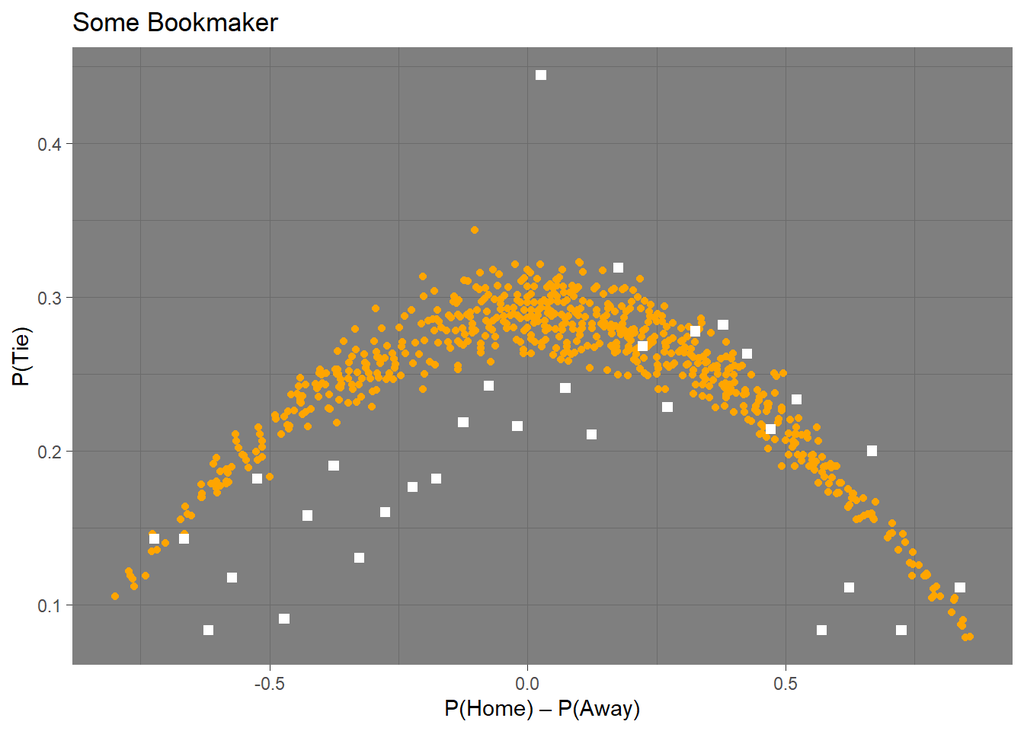

```r
ggplot(data=data,aes(x=normalized_home_IW-normalized_away_IW, y=normalized_draw_IW))+
  geom_point(color="orange")+geom_point(data=ratio,aes(meandiff,ratio),color="white",size=2,shape=15)+
  theme_dark()+xlab("P(Home) – P(Away)") + ylab("P(Tie)") + ggtitle("Some Bookmaker")
```

### Pinnacle

For the bookmaker Pinnacle, the probability calculations are done and they are normalized.

```r
data<-data%>% mutate(prob_home_PS=1/PSH)
data<-data%>% mutate(prob_away_PS=1/PSA)
data<-data%>% mutate(prob_draw_PS=1/PSD)
data<-data%>% mutate(total_prob_PS=(prob_home_PS+prob_draw_PS+prob_away_PS))
data<-data%>% mutate(normalized_home_PS=prob_home_PS/total_prob_PS)
data<-data%>% mutate(normalized_away_PS=prob_away_PS/total_prob_PS)
data<-data%>% mutate(normalized_draw_PS=prob_draw_PS/total_prob_PS)
```

The bins are created for Pinnacle with the intervals of 0.05. By counting the number of “draw” match results and dividing them by the total number of games in the corresponding bin, the estimated probabilities are obtained.

```r
bins=seq(-1,1,0.05)
draw<-data%>%filter(FTR=="D")

draw<-draw%>%mutate(interval_PS=cut(draw$normalized_home_PS-draw$normalized_away_PS,bins))
data<-data%>%mutate(interval_PS=cut(data$normalized_home_PS-data$normalized_away_PS,bins))
counted<-draw%>%group_by(interval_PS)%>%count()
counted_all<-data%>%group_by(interval_PS)%>%count()
ratio<-merge(counted,counted_all,by="interval_PS")
ratio<-ratio%>%mutate(ratio=n.x/n.y)

x<-data%>%group_by(interval_PS)%>%summarise(meandiff=mean(normalized_home_PS-normalized_away_PS))
ratio<-merge(ratio,x,by="interval_PS")
```

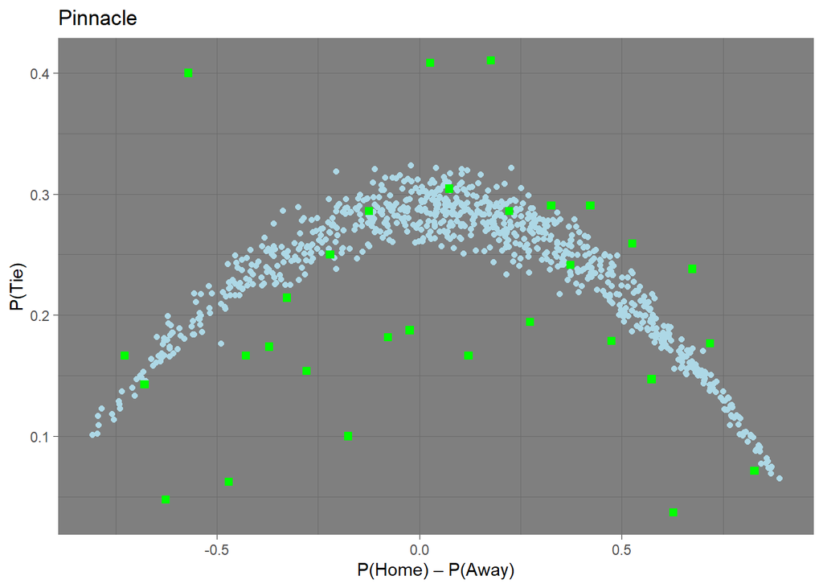

```r
ggplot(data=data,aes(x=normalized_home_PS-normalized_away_PS, y=normalized_draw_PS))+
  geom_point(color="lightblue")+geom_point(data=ratio,aes(meandiff,ratio),color="green",size=2,shape=15)+
  theme_dark()+xlab("P(Home) – P(Away)") + ylab("P(Tie)") + ggtitle("Pinnacle")
```

## 3.Task3

I removed the matches if at least one team has a red card. Then, I analysed the data again, with respect to previous 4 bookmakers.

### Bet365

```r
no_red_cards<-data%>%filter(HR=="0"&AR=="0")
draw_red<-draw%>%filter(HR=="0"&AR=="0")

counted_redcards<-draw_red%>%group_by(interval_365)%>%count()
counted_all_red<-no_red_cards%>%group_by(interval_365)%>%count()
ratio<-merge(counted_redcards,counted_all_red,by="interval_365")
ratio<-ratio%>%mutate(ratio=n.x/n.y)
x<-no_red_cards%>%group_by(interval_365)%>%summarise(meandiff=mean(normalized_home_365-normalized_away_365))
ratio<-merge(ratio,x,by="interval_365")
```

There is no significant change for this company.

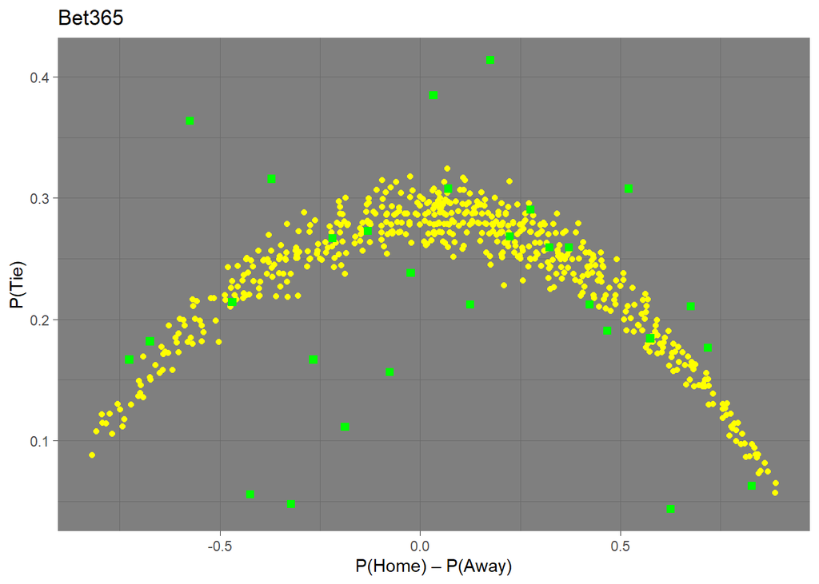

```r
no_red_cards%>%ggplot(aes(x=normalized_home_365-normalized_away_365, y=normalized_draw_365))+
  geom_point(color="yellow")+geom_point(data=ratio,aes(meandiff,ratio),color="green",size=2,shape=15)+theme_dark()+
  xlab("P(Home) – P(Away)") + ylab("P(Tie)") + ggtitle("Bet365")
```

### BetAndWin

```r
no_red_cards<-data%>%filter(HR=="0"&AR=="0")
draw_red<-draw%>%filter(HR=="0"&AR=="0")

counted_redcards<-draw_red%>%group_by(interval_BW)%>%count()
counted_all_red<-no_red_cards%>%group_by(interval_BW)%>%count()
ratio<-merge(counted_redcards,counted_all_red,by="interval_BW")
ratio<-ratio%>%mutate(ratio=n.x/n.y)
x<-no_red_cards%>%group_by(interval_BW)%>%summarise(meandiff=mean(normalized_home_BW-normalized_away_BW))
ratio<-merge(ratio,x,by="interval_BW")
```

It can be considered as there is a significant change for BetAndWin bookmaker’s observations than Task2. Now, there are more squares above the white points (bookmaker’s predictions). So, one can make much more money by betting on “Draw”.

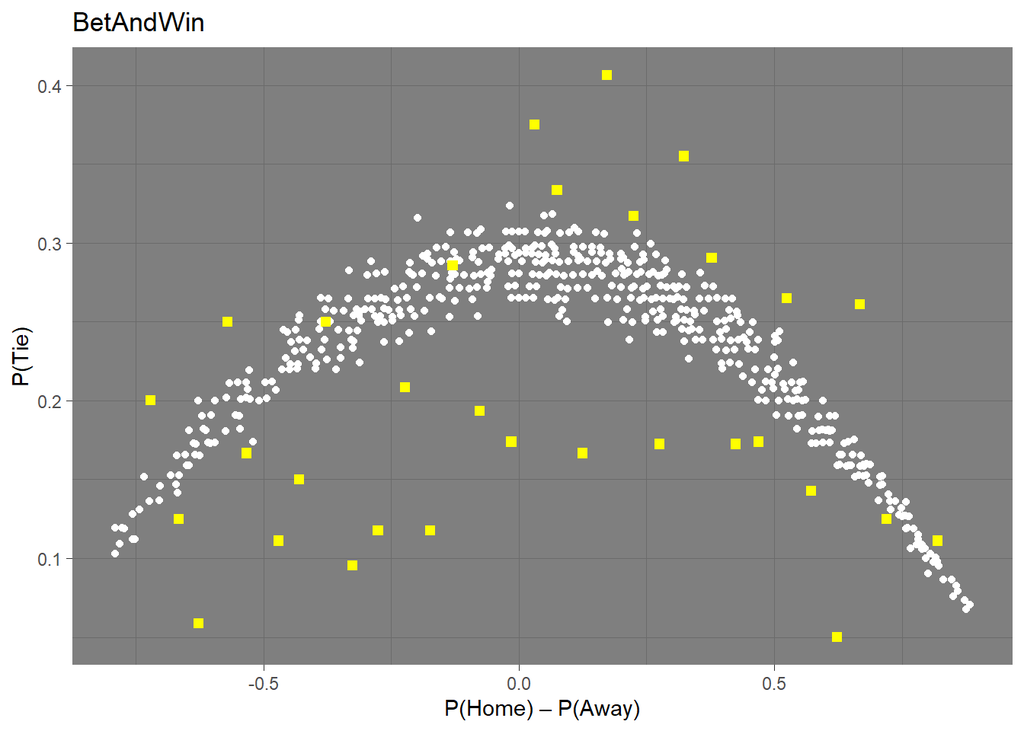

```r
no_red_cards%>%ggplot(aes(x=normalized_home_BW-normalized_away_BW, y=normalized_draw_BW))+
  geom_point(color="white")+geom_point(data=ratio,aes(meandiff,ratio),color="yellow",size=2,shape=15)+
  theme_dark()+
  xlab("P(Home) – P(Away)") + ylab("P(Tie)") + ggtitle("BetAndWin")
```

### Some Bookmaker

```r
no_red_cards<-data%>%filter(HR=="0"&AR=="0")
draw_red<-draw%>%filter(HR=="0"&AR=="0")

counted_redcards<-draw_red%>%group_by(interval_IW)%>%count()
counted_all_red<-no_red_cards%>%group_by(interval_IW)%>%count()
ratio<-merge(counted_redcards,counted_all_red,by="interval_IW")
ratio<-ratio%>%mutate(ratio=n.x/n.y)
x<-no_red_cards%>%group_by(interval_IW)%>%summarise(meandiff=mean(normalized_home_IW-normalized_away_IW))
ratio<-merge(ratio,x,by="interval_IW")
```

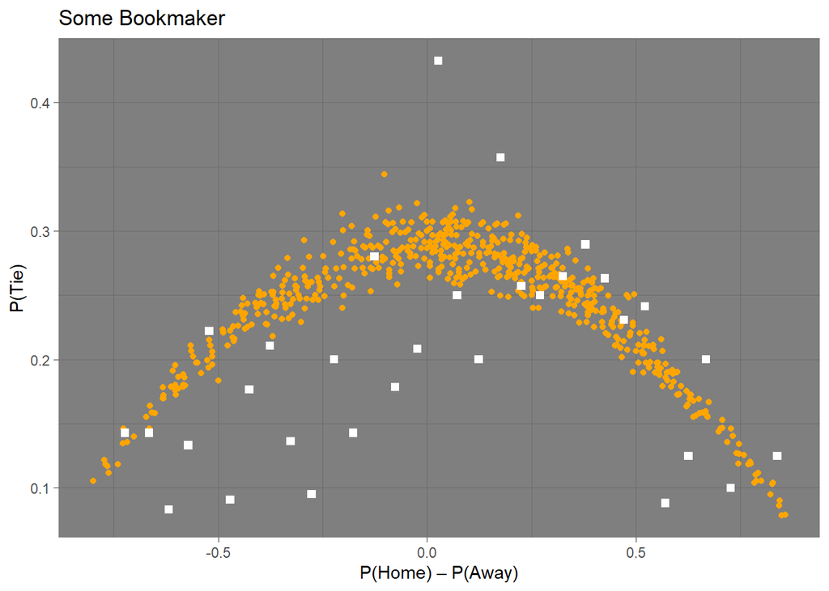

```r
no_red_cards%>%ggplot(aes(x=normalized_home_IW-normalized_away_IW, y=normalized_draw_IW))+
  geom_point(color="orange")+geom_point(data=ratio,aes(meandiff,ratio),color="white",size=2,shape=15)+
  theme_dark()+
  xlab("P(Home) – P(Away)") + ylab("P(Tie)") + ggtitle("Some Bookmaker")
```

### Pinnacle

```r
no_red_cards<-data%>%filter(HR=="0"&AR=="0")
draw_red<-draw%>%filter(HR=="0"&AR=="0")

counted_redcards<-draw_red%>%group_by(interval_PS)%>%count()
counted_all_red<-no_red_cards%>%group_by(interval_PS)%>%count()
ratio<-merge(counted_redcards,counted_all_red,by="interval_PS")
ratio<-ratio%>%mutate(ratio=n.x/n.y)
x<-no_red_cards%>%group_by(interval_PS)%>%summarise(meandiff=mean(normalized_home_PS-normalized_away_PS))
ratio<-merge(ratio,x,by="interval_PS")
```

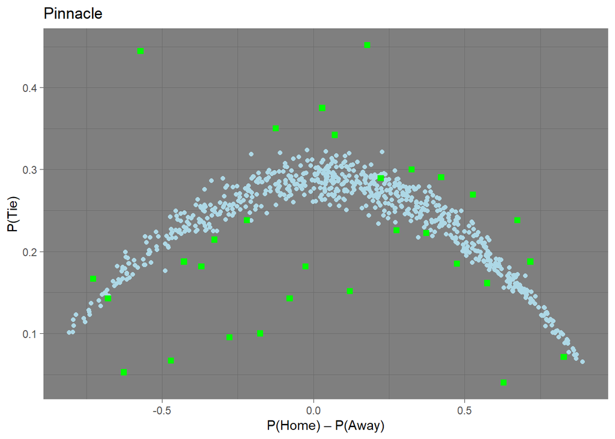

```r
no_red_cards%>%ggplot(aes(x=normalized_home_PS-normalized_away_PS, y=normalized_draw_PS))+
  geom_point(color="lightblue")+geom_point(data=ratio,aes(meandiff,ratio),color="green",size=2,shape=15)+
  theme_dark()+
  xlab("P(Home) – P(Away)") + ylab("P(Tie)") + ggtitle("Pinnacle")
```